# Risk Factor Analysis

## Outcome Variable

**Outcome Variable:** ever_stunted

## Predictor Variables

**Intervention Variable:** nrooms

**Adjustment Set:**

- arm
- sex
- W_mage
- meducyrs
- feducyrs
- hhwealth_quart
- hfoodsec
- W_mhtcm
- W_nchldlt5
- W_parity
- impfloor
- impsan
- safeh20
- delta_W_mage
- delta_meducyrs
- delta_feducyrs
- delta_hhwealth_quart
- delta_hfoodsec
- delta_W_mhtcm
- delta_W_nchldlt5
- delta_W_parity
- delta_impfloor
- delta_impsan
- delta_safeh20

## Stratifying Variables

The analysis was stratified on these variable(s):

- agecat
- studyid
- country

## Data Summary

| agecat | studyid | country | nrooms | ever_stunted | n_cell | n |
| --- | --- | --- | --- | --- | --- | --- |
| 0-6 months | ki0047075b-MAL-ED | BANGLADESH | 1 | 0 | 123 | 242 |
| 0-6 months | ki0047075b-MAL-ED | BANGLADESH | 1 | 1 | 29 | 242 |
| 0-6 months | ki0047075b-MAL-ED | BANGLADESH | 2 | 0 | 42 | 242 |
| 0-6 months | ki0047075b-MAL-ED | BANGLADESH | 2 | 1 | 8 | 242 |
| 0-6 months | ki0047075b-MAL-ED | BANGLADESH | 3 | 0 | 26 | 242 |
| 0-6 months | ki0047075b-MAL-ED | BANGLADESH | 3 | 1 | 2 | 242 |
| 0-6 months | ki0047075b-MAL-ED | BANGLADESH | 4+ | 0 | 12 | 242 |
| 0-6 months | ki0047075b-MAL-ED | BANGLADESH | 4+ | 1 | 0 | 242 |
| 0-6 months | ki0047075b-MAL-ED | BRAZIL | 1 | 0 | 4 | 210 |
| 0-6 months | ki0047075b-MAL-ED | BRAZIL | 1 | 1 | 0 | 210 |
| 0-6 months | ki0047075b-MAL-ED | BRAZIL | 2 | 0 | 19 | 210 |
| 0-6 months | ki0047075b-MAL-ED | BRAZIL | 2 | 1 | 1 | 210 |
| 0-6 months | ki0047075b-MAL-ED | BRAZIL | 3 | 0 | 52 | 210 |
| 0-6 months | ki0047075b-MAL-ED | BRAZIL | 3 | 1 | 7 | 210 |
| 0-6 months | ki0047075b-MAL-ED | BRAZIL | 4+ | 0 | 114 | 210 |
| 0-6 months | ki0047075b-MAL-ED | BRAZIL | 4+ | 1 | 13 | 210 |
| 0-6 months | ki0047075b-MAL-ED | INDIA | 1 | 0 | 75 | 235 |
| 0-6 months | ki0047075b-MAL-ED | INDIA | 1 | 1 | 9 | 235 |
| 0-6 months | ki0047075b-MAL-ED | INDIA | 2 | 0 | 59 | 235 |
| 0-6 months | ki0047075b-MAL-ED | INDIA | 2 | 1 | 19 | 235 |
| 0-6 months | ki0047075b-MAL-ED | INDIA | 3 | 0 | 39 | 235 |
| 0-6 months | ki0047075b-MAL-ED | INDIA | 3 | 1 | 9 | 235 |
| 0-6 months | ki0047075b-MAL-ED | INDIA | 4+ | 0 | 23 | 235 |
| 0-6 months | ki0047075b-MAL-ED | INDIA | 4+ | 1 | 2 | 235 |
| 0-6 months | ki0047075b-MAL-ED | NEPAL | 1 | 0 | 44 | 236 |
| 0-6 months | ki0047075b-MAL-ED | NEPAL | 1 | 1 | 8 | 236 |
| 0-6 months | ki0047075b-MAL-ED | NEPAL | 2 | 0 | 29 | 236 |
| 0-6 months | ki0047075b-MAL-ED | NEPAL | 2 | 1 | 2 | 236 |
| 0-6 months | ki0047075b-MAL-ED | NEPAL | 3 | 0 | 18 | 236 |
| 0-6 months | ki0047075b-MAL-ED | NEPAL | 3 | 1 | 4 | 236 |

[output cut: 350 more lines]

The following strata were considered:

- agecat: 0-24 months, studyid: ki0047075b-MAL-ED, country: BANGLADESH
- agecat: 0-24 months, studyid: ki0047075b-MAL-ED, country: BRAZIL
- agecat: 0-24 months, studyid: ki0047075b-MAL-ED, country: INDIA
- agecat: 0-24 months, studyid: ki0047075b-MAL-ED, country: NEPAL
- agecat: 0-24 months, studyid: ki0047075b-MAL-ED, country: PERU
- agecat: 0-24 months, studyid: ki0047075b-MAL-ED, country: SOUTH AFRICA
- agecat: 0-24 months, studyid: ki0047075b-MAL-ED, country: TANZANIA, UNITED REPUBLIC OF
- agecat: 0-24 months, studyid: ki1000108-CMC-V-BCS-2002, country: INDIA
- agecat: 0-24 months, studyid: ki1000108-IRC, country: INDIA
- agecat: 0-24 months, studyid: ki1017093b-PROVIDE, country: BANGLADESH
- agecat: 0-24 months, studyid: ki1017093c-NIH-Crypto, country: BANGLADESH
- agecat: 0-24 months, studyid: ki1113344-GMS-Nepal, country: NEPAL
- agecat: 0-24 months, studyid: ki1114097-CONTENT, country: PERU
- agecat: 0-24 months, studyid: ki1135781-COHORTS, country: INDIA
- agecat: 0-24 months, studyid: kiGH5241-JiVitA-3, country: BANGLADESH
- agecat: 0-24 months, studyid: kiGH5241-JiVitA-4, country: BANGLADESH
- agecat: 0-6 months, studyid: ki0047075b-MAL-ED, country: BANGLADESH
- agecat: 0-6 months, studyid: ki0047075b-MAL-ED, country: BRAZIL
- agecat: 0-6 months, studyid: ki0047075b-MAL-ED, country: INDIA
- agecat: 0-6 months, studyid: ki0047075b-MAL-ED, country: NEPAL
- agecat: 0-6 months, studyid: ki0047075b-MAL-ED, country: PERU
- agecat: 0-6 months, studyid: ki0047075b-MAL-ED, country: SOUTH AFRICA
- agecat: 0-6 months, studyid: ki0047075b-MAL-ED, country: TANZANIA, UNITED REPUBLIC OF
- agecat: 0-6 months, studyid: ki1000108-CMC-V-BCS-2002, country: INDIA
- agecat: 0-6 months, studyid: ki1000108-IRC, country: INDIA
- agecat: 0-6 months, studyid: ki1017093b-PROVIDE, country: BANGLADESH
- agecat: 0-6 months, studyid: ki1017093c-NIH-Crypto, country: BANGLADESH
- agecat: 0-6 months, studyid: ki1113344-GMS-Nepal, country: NEPAL
- agecat: 0-6 months, studyid: ki1114097-CONTENT, country: PERU
- agecat: 0-6 months, studyid: ki1135781-COHORTS, country: INDIA
- agecat: 0-6 months, studyid: kiGH5241-JiVitA-3, country: BANGLADESH
- agecat: 0-6 months, studyid: kiGH5241-JiVitA-4, country: BANGLADESH
- agecat: 6-24 months, studyid: ki0047075b-MAL-ED, country: BANGLADESH
- agecat: 6-24 months, studyid: ki0047075b-MAL-ED, country: BRAZIL
- agecat: 6-24 months, studyid: ki0047075b-MAL-ED, country: INDIA
- agecat: 6-24 months, studyid: ki0047075b-MAL-ED, country: NEPAL
- agecat: 6-24 months, studyid: ki0047075b-MAL-ED, country: PERU
- agecat: 6-24 months, studyid: ki0047075b-MAL-ED, country: SOUTH AFRICA
- agecat: 6-24 months, studyid: ki0047075b-MAL-ED, country: TANZANIA, UNITED REPUBLIC OF
- agecat: 6-24 months, studyid: ki1000108-CMC-V-BCS-2002, country: INDIA
- agecat: 6-24 months, studyid: ki1000108-IRC, country: INDIA
- agecat: 6-24 months, studyid: ki1017093b-PROVIDE, country: BANGLADESH
- agecat: 6-24 months, studyid: ki1017093c-NIH-Crypto, country: BANGLADESH
- agecat: 6-24 months, studyid: ki1113344-GMS-Nepal, country: NEPAL
- agecat: 6-24 months, studyid: ki1114097-CONTENT, country: PERU
- agecat: 6-24 months, studyid: ki1135781-COHORTS, country: INDIA
- agecat: 6-24 months, studyid: kiGH5241-JiVitA-3, country: BANGLADESH
- agecat: 6-24 months, studyid: kiGH5241-JiVitA-4, country: BANGLADESH

### Dropped Strata

Some strata were dropped due to rare outcomes:

## Methods Detail

We’re interested in the causal parameters $E[Y_a]$ for all values of $a \in \mathcal{A}$. These parameters represent the mean outcome if, possibly contrary to fact, we intervened to set all units to have $A=a$. Under the randomization and positivity assumptions, these are identified by the statistical parameters $\psi_a=E_W[E_{Y|A,W}(Y|A=a,W)]$. In addition, we’re interested in the mean of $Y$, $E[Y]$ under no intervention (the observed mean). We will estimate these parameters by using SuperLearner to fit the relevant likelihood factors – $E_{Y|A,W}(Y|A=a,W)$ and $p(A=a|W)$, and then updating our likelihood fit using a joint TMLE.

For unadjusted analyses ($W=\{\}$), initial likelihoods were estimated using Lrnr_glm to estimate the simple $E(Y|A)$ and Lrnr_mean to estimate $p(A)$. For adjusted analyses, a small library containing Lrnr_glmnet, Lrnr_xgboost, and Lrnr_mean was used.

Having estimated these parameters, we will then use the delta method to estimate relative risks and attributable risks relative to a prespecified baseline level of $A$.

```
##       ever_stunted
## nrooms    0
##     1  2473
##     2  1304
##     3   164
##     4+   88
```

# Results Detail

## Results Plots

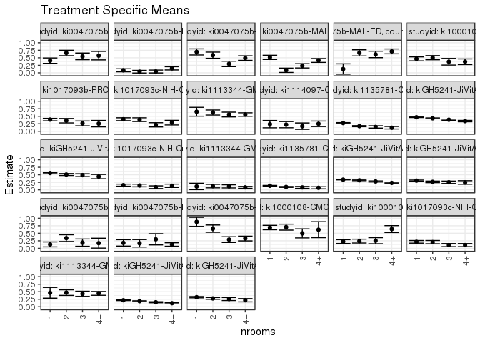

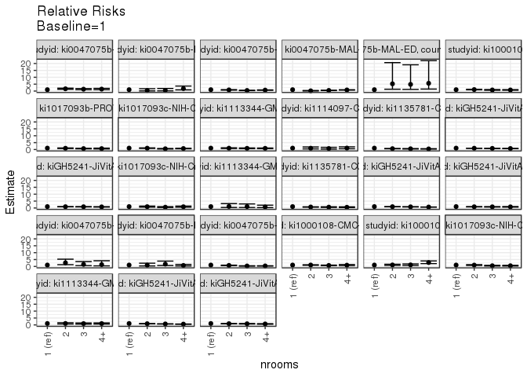

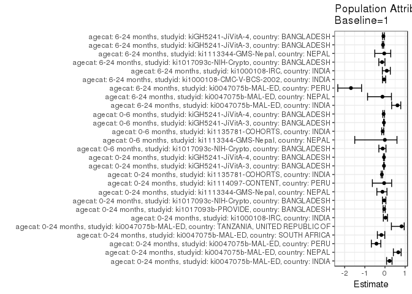

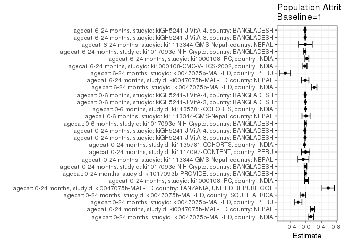

## Results Table

### Parameter: TSM

| agecat | studyid | country | intervention_level | baseline_level | estimate | ci_lower | ci_upper |
| --- | --- | --- | --- | --- | --- | --- | --- |
| 0-24 months | ki0047075b-MAL-ED | INDIA | 1 | NA | 0.4045036 | 0.3148643 | 0.4941429 |
| 0-24 months | ki0047075b-MAL-ED | INDIA | 2 | NA | 0.6603028 | 0.5703718 | 0.7502339 |
| 0-24 months | ki0047075b-MAL-ED | INDIA | 3 | NA | 0.5466612 | 0.4353482 | 0.6579741 |
| 0-24 months | ki0047075b-MAL-ED | INDIA | 4+ | NA | 0.5716279 | 0.4297713 | 0.7134845 |
| 0-24 months | ki0047075b-MAL-ED | NEPAL | 1 | NA | 0.0835813 | 0.0325700 | 0.1345926 |
| 0-24 months | ki0047075b-MAL-ED | NEPAL | 2 | NA | 0.0374245 | -0.0065280 | 0.0813770 |
| 0-24 months | ki0047075b-MAL-ED | NEPAL | 3 | NA | 0.0437495 | -0.0045321 | 0.0920312 |
| 0-24 months | ki0047075b-MAL-ED | NEPAL | 4+ | NA | 0.1486930 | 0.0953961 | 0.2019899 |
| 0-24 months | ki0047075b-MAL-ED | PERU | 1 | NA | 0.6956382 | 0.5942297 | 0.7970467 |
| 0-24 months | ki0047075b-MAL-ED | PERU | 2 | NA | 0.5858952 | 0.4825777 | 0.6892126 |
| 0-24 months | ki0047075b-MAL-ED | PERU | 3 | NA | 0.2961127 | 0.2058040 | 0.3864213 |
| 0-24 months | ki0047075b-MAL-ED | PERU | 4+ | NA | 0.4899409 | 0.4137880 | 0.5660937 |
| 0-24 months | ki0047075b-MAL-ED | SOUTH AFRICA | 1 | NA | 0.5136860 | 0.4439082 | 0.5834638 |
| 0-24 months | ki0047075b-MAL-ED | SOUTH AFRICA | 2 | NA | 0.0842809 | 0.0127932 | 0.1557686 |
| 0-24 months | ki0047075b-MAL-ED | SOUTH AFRICA | 3 | NA | 0.2322801 | 0.1609242 | 0.3036360 |
| 0-24 months | ki0047075b-MAL-ED | SOUTH AFRICA | 4+ | NA | 0.4109655 | 0.3468338 | 0.4750971 |
| 0-24 months | ki0047075b-MAL-ED | TANZANIA, UNITED REPUBLIC OF | 1 | NA | 0.1263682 | -0.0456807 | 0.2984171 |
| 0-24 months | ki0047075b-MAL-ED | TANZANIA, UNITED REPUBLIC OF | 2 | NA | 0.6641963 | 0.5624224 | 0.7659702 |
| 0-24 months | ki0047075b-MAL-ED | TANZANIA, UNITED REPUBLIC OF | 3 | NA | 0.6115460 | 0.5040296 | 0.7190623 |
| 0-24 months | ki0047075b-MAL-ED | TANZANIA, UNITED REPUBLIC OF | 4+ | NA | 0.7126244 | 0.6315998 | 0.7936491 |
| 0-24 months | ki1000108-IRC | INDIA | 1 | NA | 0.4649363 | 0.3988024 | 0.5310701 |
| 0-24 months | ki1000108-IRC | INDIA | 2 | NA | 0.5029160 | 0.4334469 | 0.5723850 |
| 0-24 months | ki1000108-IRC | INDIA | 3 | NA | 0.3690305 | 0.2579242 | 0.4801368 |
| 0-24 months | ki1000108-IRC | INDIA | 4+ | NA | 0.3680929 | 0.2741785 | 0.4620073 |
| 0-24 months | ki1017093b-PROVIDE | BANGLADESH | 1 | NA | 0.3897823 | 0.3488340 | 0.4307307 |
| 0-24 months | ki1017093b-PROVIDE | BANGLADESH | 2 | NA | 0.3528594 | 0.2797712 | 0.4259477 |
| 0-24 months | ki1017093b-PROVIDE | BANGLADESH | 3 | NA | 0.2629660 | 0.1827395 | 0.3431925 |
| 0-24 months | ki1017093b-PROVIDE | BANGLADESH | 4+ | NA | 0.2549734 | 0.1485617 | 0.3613851 |
| 0-24 months | ki1017093c-NIH-Crypto | BANGLADESH | 1 | NA | 0.4018133 | 0.3541312 | 0.4494954 |
| 0-24 months | ki1017093c-NIH-Crypto | BANGLADESH | 2 | NA | 0.3871058 | 0.3249040 | 0.4493075 |

[output cut: 78 more lines]

### Parameter: E(Y)

| agecat | studyid | country | intervention_level | baseline_level | estimate | ci_lower | ci_upper |
| --- | --- | --- | --- | --- | --- | --- | --- |
| 0-24 months | ki0047075b-MAL-ED | INDIA | NA | NA | 0.5234043 | 0.4594110 | 0.5873975 |
| 0-24 months | ki0047075b-MAL-ED | NEPAL | NA | NA | 0.2457627 | 0.1907167 | 0.3008088 |
| 0-24 months | ki0047075b-MAL-ED | PERU | NA | NA | 0.4889706 | 0.4294554 | 0.5484858 |
| 0-24 months | ki0047075b-MAL-ED | SOUTH AFRICA | NA | NA | 0.4357977 | 0.3750558 | 0.4965395 |
| 0-24 months | ki0047075b-MAL-ED | TANZANIA, UNITED REPUBLIC OF | NA | NA | 0.7120000 | 0.6557549 | 0.7682451 |
| 0-24 months | ki1000108-IRC | INDIA | NA | NA | 0.4779412 | 0.4294126 | 0.5264698 |
| 0-24 months | ki1017093b-PROVIDE | BANGLADESH | NA | NA | 0.3757143 | 0.3398113 | 0.4116172 |
| 0-24 months | ki1017093c-NIH-Crypto | BANGLADESH | NA | NA | 0.3878628 | 0.3531521 | 0.4225735 |
| 0-24 months | ki1113344-GMS-Nepal | NEPAL | NA | NA | 0.5780731 | 0.5385891 | 0.6175571 |
| 0-24 months | ki1114097-CONTENT | PERU | NA | NA | 0.2279070 | 0.1717046 | 0.2841094 |
| 0-24 months | ki1135781-COHORTS | INDIA | NA | NA | 0.2370674 | 0.2256958 | 0.2484389 |
| 0-24 months | kiGH5241-JiVitA-3 | BANGLADESH | NA | NA | 0.4438727 | 0.4363510 | 0.4513944 |
| 0-24 months | kiGH5241-JiVitA-4 | BANGLADESH | NA | NA | 0.5322521 | 0.5160648 | 0.5484394 |
| 0-6 months | ki1017093c-NIH-Crypto | BANGLADESH | NA | NA | 0.1385224 | 0.1139141 | 0.1631308 |
| 0-6 months | ki1113344-GMS-Nepal | NEPAL | NA | NA | 0.1112957 | 0.0861520 | 0.1364394 |
| 0-6 months | ki1135781-COHORTS | INDIA | NA | NA | 0.1217023 | 0.1128092 | 0.1305953 |
| 0-6 months | kiGH5241-JiVitA-3 | BANGLADESH | NA | NA | 0.3219971 | 0.3152345 | 0.3287596 |
| 0-6 months | kiGH5241-JiVitA-4 | BANGLADESH | NA | NA | 0.2864960 | 0.2726657 | 0.3003263 |
| 6-24 months | ki0047075b-MAL-ED | INDIA | NA | NA | 0.3402062 | 0.2733649 | 0.4070475 |
| 6-24 months | ki0047075b-MAL-ED | NEPAL | NA | NA | 0.1607143 | 0.1125109 | 0.2089177 |
| 6-24 months | ki0047075b-MAL-ED | PERU | NA | NA | 0.3275109 | 0.2665942 | 0.3884276 |
| 6-24 months | ki1000108-CMC-V-BCS-2002 | INDIA | NA | NA | 0.6631944 | 0.6085159 | 0.7178730 |
| 6-24 months | ki1000108-IRC | INDIA | NA | NA | 0.2462908 | 0.2002223 | 0.2923593 |
| 6-24 months | ki1017093c-NIH-Crypto | BANGLADESH | NA | NA | 0.1887097 | 0.1578857 | 0.2195336 |
| 6-24 months | ki1113344-GMS-Nepal | NEPAL | NA | NA | 0.4479167 | 0.4033837 | 0.4924496 |
| 6-24 months | kiGH5241-JiVitA-3 | BANGLADESH | NA | NA | 0.1969914 | 0.1889397 | 0.2050430 |
| 6-24 months | kiGH5241-JiVitA-4 | BANGLADESH | NA | NA | 0.2954018 | 0.2790421 | 0.3117615 |

### Parameter: RR

| agecat | studyid | country | intervention_level | baseline_level | estimate | ci_lower | ci_upper |
| --- | --- | --- | --- | --- | --- | --- | --- |
| 0-24 months | ki0047075b-MAL-ED | INDIA | 1 | 1 | 1.0000000 | 1.0000000 | 1.0000000 |
| 0-24 months | ki0047075b-MAL-ED | INDIA | 2 | 1 | 1.6323780 | 1.2693660 | 2.0992036 |
| 0-24 months | ki0047075b-MAL-ED | INDIA | 3 | 1 | 1.3514369 | 1.0143527 | 1.8005392 |
| 0-24 months | ki0047075b-MAL-ED | INDIA | 4+ | 1 | 1.4131588 | 1.0238518 | 1.9504951 |
| 0-24 months | ki0047075b-MAL-ED | NEPAL | 1 | 1 | 1.0000000 | 1.0000000 | 1.0000000 |
| 0-24 months | ki0047075b-MAL-ED | NEPAL | 2 | 1 | 0.4477616 | 0.1179805 | 1.6993517 |
| 0-24 months | ki0047075b-MAL-ED | NEPAL | 3 | 1 | 0.5234368 | 0.1469293 | 1.8647475 |
| 0-24 months | ki0047075b-MAL-ED | NEPAL | 4+ | 1 | 1.7790216 | 0.8711414 | 3.6330702 |
| 0-24 months | ki0047075b-MAL-ED | PERU | 1 | 1 | 1.0000000 | 1.0000000 | 1.0000000 |
| 0-24 months | ki0047075b-MAL-ED | PERU | 2 | 1 | 0.8422412 | 0.6703967 | 1.0581352 |
| 0-24 months | ki0047075b-MAL-ED | PERU | 3 | 1 | 0.4256705 | 0.3045103 | 0.5950386 |
| 0-24 months | ki0047075b-MAL-ED | PERU | 4+ | 1 | 0.7043042 | 0.5707430 | 0.8691204 |
| 0-24 months | ki0047075b-MAL-ED | SOUTH AFRICA | 1 | 1 | 1.0000000 | 1.0000000 | 1.0000000 |
| 0-24 months | ki0047075b-MAL-ED | SOUTH AFRICA | 2 | 1 | 0.1640709 | 0.0700382 | 0.3843508 |
| 0-24 months | ki0047075b-MAL-ED | SOUTH AFRICA | 3 | 1 | 0.4521831 | 0.3278277 | 0.6237104 |
| 0-24 months | ki0047075b-MAL-ED | SOUTH AFRICA | 4+ | 1 | 0.8000325 | 0.6621700 | 0.9665976 |
| 0-24 months | ki0047075b-MAL-ED | TANZANIA, UNITED REPUBLIC OF | 1 | 1 | 1.0000000 | 1.0000000 | 1.0000000 |
| 0-24 months | ki0047075b-MAL-ED | TANZANIA, UNITED REPUBLIC OF | 2 | 1 | 5.2560402 | 1.3392543 | 20.6278665 |
| 0-24 months | ki0047075b-MAL-ED | TANZANIA, UNITED REPUBLIC OF | 3 | 1 | 4.8393980 | 1.2295744 | 19.0470571 |
| 0-24 months | ki0047075b-MAL-ED | TANZANIA, UNITED REPUBLIC OF | 4+ | 1 | 5.6392709 | 1.4420375 | 22.0530855 |
| 0-24 months | ki1000108-IRC | INDIA | 1 | 1 | 1.0000000 | 1.0000000 | 1.0000000 |
| 0-24 months | ki1000108-IRC | INDIA | 2 | 1 | 1.0816880 | 0.8883334 | 1.3171280 |
| 0-24 months | ki1000108-IRC | INDIA | 3 | 1 | 0.7937227 | 0.5691443 | 1.1069175 |
| 0-24 months | ki1000108-IRC | INDIA | 4+ | 1 | 0.7917061 | 0.5918395 | 1.0590685 |
| 0-24 months | ki1017093b-PROVIDE | BANGLADESH | 1 | 1 | 1.0000000 | 1.0000000 | 1.0000000 |
| 0-24 months | ki1017093b-PROVIDE | BANGLADESH | 2 | 1 | 0.9052730 | 0.7228286 | 1.1337671 |
| 0-24 months | ki1017093b-PROVIDE | BANGLADESH | 3 | 1 | 0.6746483 | 0.4917901 | 0.9254973 |
| 0-24 months | ki1017093b-PROVIDE | BANGLADESH | 4+ | 1 | 0.6541431 | 0.4268137 | 1.0025526 |
| 0-24 months | ki1017093c-NIH-Crypto | BANGLADESH | 1 | 1 | 1.0000000 | 1.0000000 | 1.0000000 |
| 0-24 months | ki1017093c-NIH-Crypto | BANGLADESH | 2 | 1 | 0.9633972 | 0.7914248 | 1.1727382 |

[output cut: 78 more lines]

### Parameter: PAR

| agecat | studyid | country | intervention_level | baseline_level | estimate | ci_lower | ci_upper |
| --- | --- | --- | --- | --- | --- | --- | --- |
| 0-24 months | ki0047075b-MAL-ED | INDIA | 1 | NA | 0.1189006 | 0.0485067 | 0.1892946 |
| 0-24 months | ki0047075b-MAL-ED | NEPAL | 1 | NA | 0.1621814 | 0.1080854 | 0.2162773 |
| 0-24 months | ki0047075b-MAL-ED | PERU | 1 | NA | -0.2066676 | -0.3099240 | -0.1034112 |
| 0-24 months | ki0047075b-MAL-ED | SOUTH AFRICA | 1 | NA | -0.0778883 | -0.1518683 | -0.0039083 |
| 0-24 months | ki0047075b-MAL-ED | TANZANIA, UNITED REPUBLIC OF | 1 | NA | 0.5856318 | 0.4179799 | 0.7532837 |
| 0-24 months | ki1000108-IRC | INDIA | 1 | NA | 0.0130049 | -0.0361205 | 0.0621303 |
| 0-24 months | ki1017093b-PROVIDE | BANGLADESH | 1 | NA | -0.0140680 | -0.0334151 | 0.0052790 |
| 0-24 months | ki1017093c-NIH-Crypto | BANGLADESH | 1 | NA | -0.0139505 | -0.0470508 | 0.0191498 |
| 0-24 months | ki1113344-GMS-Nepal | NEPAL | 1 | NA | -0.0720998 | -0.2152166 | 0.0710170 |
| 0-24 months | ki1114097-CONTENT | PERU | 1 | NA | -0.0096718 | -0.1152374 | 0.0958938 |
| 0-24 months | ki1135781-COHORTS | INDIA | 1 | NA | -0.0365910 | -0.0442426 | -0.0289394 |
| 0-24 months | kiGH5241-JiVitA-3 | BANGLADESH | 1 | NA | -0.0224033 | -0.0277343 | -0.0170723 |
| 0-24 months | kiGH5241-JiVitA-4 | BANGLADESH | 1 | NA | -0.0258715 | -0.0389342 | -0.0128087 |
| 0-6 months | ki1017093c-NIH-Crypto | BANGLADESH | 1 | NA | -0.0156395 | -0.0399356 | 0.0086567 |
| 0-6 months | ki1113344-GMS-Nepal | NEPAL | 1 | NA | -0.0006176 | -0.1025262 | 0.1012910 |
| 0-6 months | ki1135781-COHORTS | INDIA | 1 | NA | -0.0136411 | -0.0196116 | -0.0076705 |
| 0-6 months | kiGH5241-JiVitA-3 | BANGLADESH | 1 | NA | -0.0167643 | -0.0220371 | -0.0114916 |
| 0-6 months | kiGH5241-JiVitA-4 | BANGLADESH | 1 | NA | -0.0190345 | -0.0305939 | -0.0074750 |
| 6-24 months | ki0047075b-MAL-ED | INDIA | 1 | NA | 0.2105311 | 0.1340991 | 0.2869630 |
| 6-24 months | ki0047075b-MAL-ED | NEPAL | 1 | NA | -0.0200384 | -0.1115846 | 0.0715079 |
| 6-24 months | ki0047075b-MAL-ED | PERU | 1 | NA | -0.5525977 | -0.6999484 | -0.4052470 |
| 6-24 months | ki1000108-CMC-V-BCS-2002 | INDIA | 1 | NA | -0.0276211 | -0.0793044 | 0.0240622 |
| 6-24 months | ki1000108-IRC | INDIA | 1 | NA | 0.0220100 | -0.0267485 | 0.0707684 |
| 6-24 months | ki1017093c-NIH-Crypto | BANGLADESH | 1 | NA | -0.0271468 | -0.0557265 | 0.0014330 |
| 6-24 months | ki1113344-GMS-Nepal | NEPAL | 1 | NA | -0.0163885 | -0.1894106 | 0.1566336 |
| 6-24 months | kiGH5241-JiVitA-3 | BANGLADESH | 1 | NA | -0.0193207 | -0.0255704 | -0.0130710 |
| 6-24 months | kiGH5241-JiVitA-4 | BANGLADESH | 1 | NA | -0.0228922 | -0.0360373 | -0.0097472 |

### Parameter: PAF

| agecat | studyid | country | intervention_level | baseline_level | estimate | ci_lower | ci_upper |
| --- | --- | --- | --- | --- | --- | --- | --- |
| 0-24 months | ki0047075b-MAL-ED | INDIA | 1 | NA | 0.2271678 | 0.0805752 | 0.3503878 |
| 0-24 months | ki0047075b-MAL-ED | NEPAL | 1 | NA | 0.6599105 | 0.4167668 | 0.8016902 |
| 0-24 months | ki0047075b-MAL-ED | PERU | 1 | NA | -0.4226585 | -0.6755228 | -0.2079556 |
| 0-24 months | ki0047075b-MAL-ED | SOUTH AFRICA | 1 | NA | -0.1787258 | -0.3766636 | -0.0092477 |
| 0-24 months | ki0047075b-MAL-ED | TANZANIA, UNITED REPUBLIC OF | 1 | NA | 0.8225166 | 0.3190117 | 0.9537432 |
| 0-24 months | ki1000108-IRC | INDIA | 1 | NA | 0.0272102 | -0.0809887 | 0.1245793 |
| 0-24 months | ki1017093b-PROVIDE | BANGLADESH | 1 | NA | -0.0374435 | -0.0903312 | 0.0128789 |
| 0-24 months | ki1017093c-NIH-Crypto | BANGLADESH | 1 | NA | -0.0359675 | -0.1250281 | 0.0460428 |
| 0-24 months | ki1113344-GMS-Nepal | NEPAL | 1 | NA | -0.1247244 | -0.4020436 | 0.0977421 |
| 0-24 months | ki1114097-CONTENT | PERU | 1 | NA | -0.0424376 | -0.6250102 | 0.3312804 |
| 0-24 months | ki1135781-COHORTS | INDIA | 1 | NA | -0.1543486 | -0.1872466 | -0.1223622 |
| 0-24 months | kiGH5241-JiVitA-3 | BANGLADESH | 1 | NA | -0.0504724 | -0.0626285 | -0.0384553 |
| 0-24 months | kiGH5241-JiVitA-4 | BANGLADESH | 1 | NA | -0.0486076 | -0.0736004 | -0.0241965 |
| 0-6 months | ki1017093c-NIH-Crypto | BANGLADESH | 1 | NA | -0.1129023 | -0.3034299 | 0.0497751 |
| 0-6 months | ki1113344-GMS-Nepal | NEPAL | 1 | NA | -0.0055491 | -1.4994293 | 0.5954561 |
| 0-6 months | ki1135781-COHORTS | INDIA | 1 | NA | -0.1120856 | -0.1621334 | -0.0641931 |
| 0-6 months | kiGH5241-JiVitA-3 | BANGLADESH | 1 | NA | -0.0520636 | -0.0686660 | -0.0357192 |
| 0-6 months | kiGH5241-JiVitA-4 | BANGLADESH | 1 | NA | -0.0664389 | -0.1074711 | -0.0269270 |
| 6-24 months | ki0047075b-MAL-ED | INDIA | 1 | NA | 0.6188337 | 0.3306783 | 0.7829329 |
| 6-24 months | ki0047075b-MAL-ED | NEPAL | 1 | NA | -0.1246832 | -0.8633110 | 0.3211481 |
| 6-24 months | ki0047075b-MAL-ED | PERU | 1 | NA | -1.6872650 | -2.3408408 | -1.1615496 |
| 6-24 months | ki1000108-CMC-V-BCS-2002 | INDIA | 1 | NA | -0.0416486 | -0.1228295 | 0.0336630 |
| 6-24 months | ki1000108-IRC | INDIA | 1 | NA | 0.0893657 | -0.1298510 | 0.2660495 |
| 6-24 months | ki1017093c-NIH-Crypto | BANGLADESH | 1 | NA | -0.1438546 | -0.3059743 | -0.0018600 |
| 6-24 months | ki1113344-GMS-Nepal | NEPAL | 1 | NA | -0.0365883 | -0.5047096 | 0.2858986 |
| 6-24 months | kiGH5241-JiVitA-3 | BANGLADESH | 1 | NA | -0.0980789 | -0.1304190 | -0.0666640 |
| 6-24 months | kiGH5241-JiVitA-4 | BANGLADESH | 1 | NA | -0.0774953 | -0.1228614 | -0.0339621 |